# Models and Vis for SPF

Nick Gawron

2023-03-27

```r
# test train function
trte<-function(dataf,p=.8){

  tr_id<-sample(1:nrow(dataf),p*nrow(dataf))

  train<-dataf[tr_id,]

  test<-dataf[-tr_id,]

  return(list(train,test))
}


trte_seed<-function(dataf,p=.8,seedv=123){

  set.seed(seedv)
  tr_id<-sample(1:nrow(dataf),p*nrow(dataf))

  train<-dataf[tr_id,]

  test<-dataf[-tr_id,]

  return(list(train,test))
}
```

```r
# function to compute test set RMSE on the spfc variable given a model and test set
crmse<-function(model,test,var="Sweetpotato_Flavor"){

  preds<-predict(model,test)

  obs<-test[,var]

  rmse<-sqrt( mean((preds-obs)^2))

  return(rmse)
}
```

```r
# gets the best tuned model from a caret fitted model
get_best_result = function(caret_fit) {
  best = which(rownames(caret_fit$results) == rownames(caret_fit$bestTune))
  best_result = caret_fit$results[best, ]
  rownames(best_result) = NULL
  best_result
}
```

# Reading in Data

- We only deal with the 40 observations that have record for at least one VOC
- Testing and training sets allow us to evaluate the performance of statistical models.
- A testing set provides an unbiased estimate of the model’s performance on new, unseen data.
- A training set is used to fit the model parameters, and having separate training and testing sets helps to prevent **overfitting**, where a model learns to perform well on the training data but does not generalize well to new data.
- Without a testing set, we might mistakenly believe that our model is performing well when in fact it is overfitting to the training data.
- A testing set can also be used to compare the performance of different models or variations of the same model.
- In addition, a validation set can be used during the training process to tune hyperparameters or select the best model based on performance on the validation set.
- Ultimately, having separate training and testing sets helps us build more accurate and reliable statistical models.

Cross Validation is a process that is used to pick the optimal hyperparameters for a model.

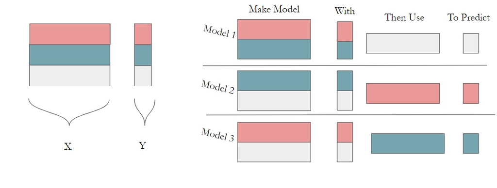

Cross Validation Image

# Explaining Some Models

```r
 train_test<-trte(Xy)
  train<-train_test[[1]]
  test<-train_test[[2]]
```

```r
dim(train)
```

```
## [1]  32 404
```

We test our model on 8 points!

```r
dim(test)
```

```
## [1]   8 404
```

# PLS

- PCR makes new columns to describe as much as possible the variation in the data of VOC concentrations.
- However nothing guarantees that the principal components, which “explain” VOC’s optimally, will be relevant for the prediction of Sweet Potato Flavor.
- Solution: incorporate information from Sweet Potato Flavor when choosing the projection. We thus choose a projection that describes as well as possible the covariation of data VOC’s and labels Sweet Potato Flavor.

Advantages of Partial Least Squares:

1. It can handle high-dimensional data with multicollinearity.
2. It can handle small sample sizes with more predictor variables than observations.
3. It can perform dimensionality reduction while preserving most of the variation in the data.
4. It can deal with both continuous and categorical predictor variables.
5. It can handle missing data by using available data to estimate missing values.
6. It can be used for both regression and classification problems.

Disadvantages of Partial Least Squares:

```r
set.seed(1001)
## Set K=30
  pcgrid <- expand.grid(ncomp = 1:20)
## Training control params
  cv <- trainControl(method = "cv",number = 5)
## Fit the model
  pls_fit <- train(Sweetpotato_Flavor ~ .,
                   data = train,
                   method = "pls",
                   tuneGrid = pcgrid,
                   trControl = cv,
                   preProcess=c("center","scale"))
```

- *Partial Least Squares:* the variable importance measure here is based on weighted sums of the absolute regression coefficients. The weights are a function of the reduction of the sums of squares across the number of PLS components and are computed separately for each outcome. Therefore, the contribution of the coefficients are weighted proportionally to the reduction in the sums of squares.

```r
plsrmse<-crmse(pls_fit,test)
```

```r
importance<-varImp(pls_fit)
```

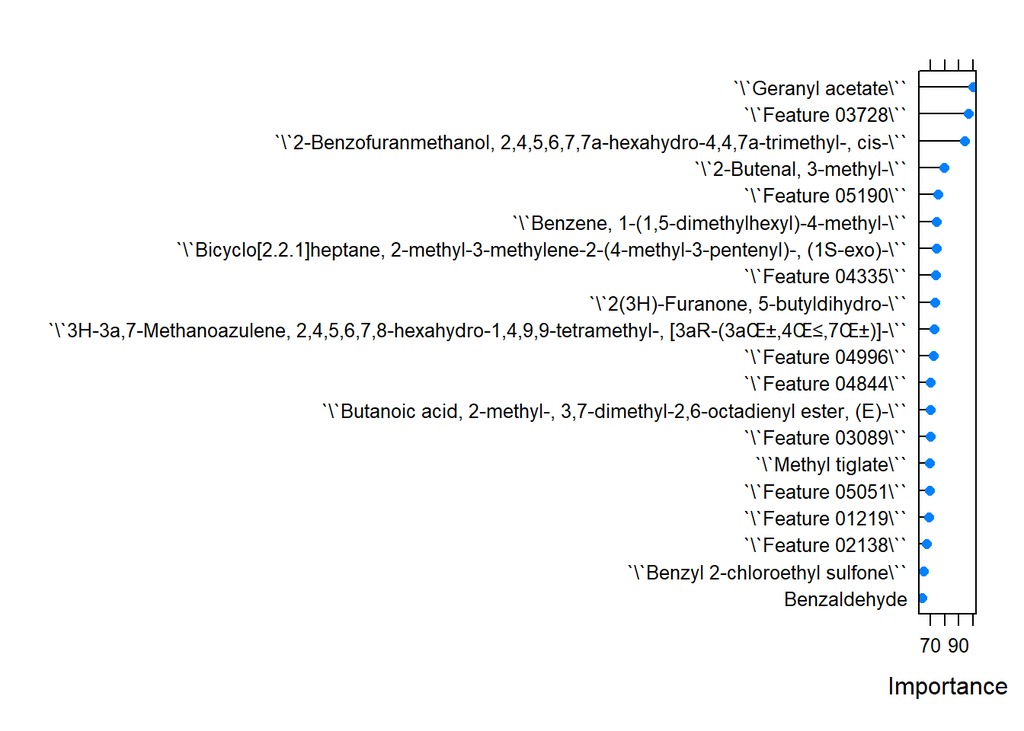

```r
plot(importance,top=20)
```

## Lasso

- LASSO (Least Absolute Shrinkage and Selection Operator) is a regression analysis technique used for feature selection and regularization. It aims to reduce the complexity of a regression model by shrinking the coefficients of some predictors to zero, effectively selecting only the most important predictors.
- LASSO is particularly useful in high-dimensional data sets where the number of predictors is much larger than the number of observations. By reducing the number of predictors, LASSO can improve the accuracy of the model and prevent overfitting.
- This model selects important variables! It does this by setting not important ones to zero

$$\texttt{minimize}: \sum_{i=1}^n (y_i -
\beta_0 - \sum_{j=1}^p x_{ij}\beta_j)^2 + \lambda \sum_{j=1}^p
|\beta_j|$$

In plain old Regression we try and minimize the below function to get our “slopes”. See how it is similar to the LASSO function

$$\sum_{i=1}^n (y_i - \beta_0 -
\sum_{j=1}^p x_{ij}\beta_j)^2$$

```r
tuneGrid <- expand.grid(alpha = 1, lambda = seq(0.0001, 1, length = 40))


lasso_fit <- train(
  Sweetpotato_Flavor ~.,
  data = train,
  method = "glmnet",
  trControl = trainControl("cv", number = 5),
  tuneGrid =tuneGrid,
  preProcess=c("scale")
)
```

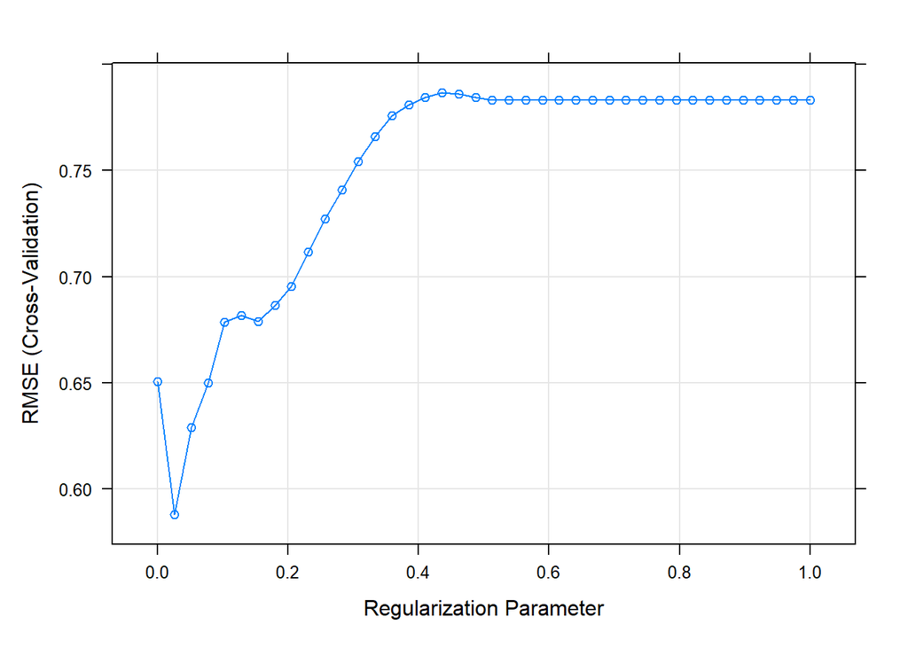

```r
plot(lasso_fit)
```

- Now we can look at the optimal terms

```r
library(glmnet)
## model matrix (standardized) and response
  model_mat <-train%>%select(-Sweetpotato_Flavor)
  model_mat <- scale(model_mat)
  model_mat <- as.matrix(model_mat)

## Fit lasso regression for a grid of lambda
grid <- 10^seq(-3, 7, length = 100)

  spf_lasso <- cv.glmnet(x = model_mat, y = train$Sweetpotato_Flavor,
  alpha = 1,
  lambda = grid,
  nfolds = 5)

beta_hat <- coef(spf_lasso)


#prints out kept values
sort(as.matrix(coef(spf_lasso, spf_lasso$lambda.1se))[as.matrix(coef(spf_lasso, spf_lasso$lambda.1se))!=0,],decreasing = T)
```

```
##                                                          (Intercept)
##                                                           3.15550595
##                                                        Feature 03089
##                                                           0.09389805
##                                                        Feature 05051
##                                                           0.09000189
##                                                        Feature 02540
##                                                           0.01369528
##                                      2(3H)-Furanone, 5-butyldihydro-
##                                                          -0.02611702
##                             Benzene, 1-(1,5-dimethylhexyl)-4-methyl-
##                                                          -0.07301499
## 2-Benzofuranmethanol, 2,4,5,6,7,7a-hexahydro-4,4,7a-trimethyl-, cis-
##                                                          -0.08843080
##                                                      Geranyl acetate
##                                                          -0.16078417
```

```r
sort(as.matrix(coef(spf_lasso, spf_lasso$lambda.min))[as.matrix(coef(spf_lasso, spf_lasso$lambda.min))!=0,],decreasing = T)
```

```
##                                                          (Intercept)
##                                                         3.1555059524
##                                                        Feature 04198
##                                                         0.1841390830
##                                                        Feature 03089
##                                                         0.1551560570
##                                                        Feature 04166
##                                                         0.1083694191
##                                                        Feature 02060
##                                                         0.0897459187
##                                                        Feature 02540
##                                                         0.0410709326
##                                                        Feature 04778
##                                                         0.0309003485
##                                                        Feature 02991
##                                                         0.0002965783
##                                      2(3H)-Furanone, 5-butyldihydro-
##                                                        -0.0088998761
##                                                        Feature 01901
##                                                        -0.0132567575
##                                                       Methyl Alcohol
##                                                        -0.0134269989
##                  Benzene, 1-(1,5-dimethyl-4-hexenyl)-4-methyl-...100
##                                                        -0.0135470858
##                                                        Feature 05596
##                                                        -0.0342427580
##                                         Benzyl 2-chloroethyl sulfone
##                                                        -0.0367097528
##                                                        Feature 02170
##                                                        -0.0571675655
## 2-Benzofuranmethanol, 2,4,5,6,7,7a-hexahydro-4,4,7a-trimethyl-, cis-
##                                                        -0.0922999273
##                             Benzene, 1-(1,5-dimethylhexyl)-4-methyl-
##                                                        -0.1041437049
##                                                        Feature 05593
##                                                        -0.1267457850
##                                             Butanenitrile, 2-methyl-
##                                                        -0.1505319587
##                                                      Geranyl acetate
##                                                        -0.3504113837
```

# Elastic Net

- Let us use All the VOCs
- Elastic Net is an extension of LASSO
  - We have another term in the LOSS function that tells the “slopes” to not be as severe
- This model also picks out the “best coefficents”

Recall the $\alpha$ and $\lambda$ tuning parameters from the ppt.

```r
tuneGrid <- expand.grid(alpha = seq(0,1,length=10), lambda = seq(0.0001, 1, length = 40))


enet_fit <- train(
  Sweetpotato_Flavor ~.,
  data = train,
  method = "glmnet",
  trControl = trainControl("cv", number = 5),
  tuneGrid =tuneGrid,
  preProcess=c("scale")
)
```

- Here is the plot for figuring out the best $\lambda_i$

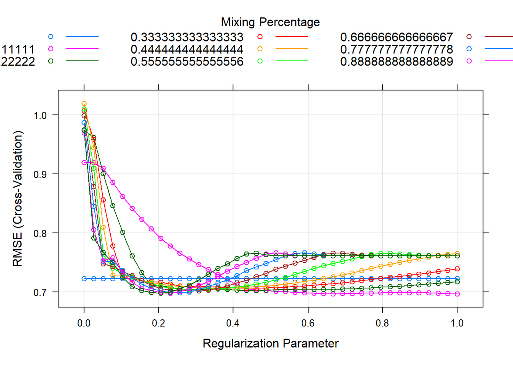

```r
best_enn<-get_best_result(enet_fit)
plot(enet_fit)
```

```r
best_enn
```

```
##       alpha lambda      RMSE  Rsquared       MAE   RMSESD RsquaredSD     MAESD
## 1 0.1111111      1 0.6968996 0.2889108 0.5445343 0.155698  0.2097056 0.1166321
```

- Now we can look at the optimal terms

```r
  spf_lasso_final <- glmnet(x = model_mat, y = train$Sweetpotato_Flavor,
  alpha = best_enn$alpha,
  lambda = best_enn$lambda)


sigvals<-sort(as.matrix(coef(spf_lasso_final, spf_lasso_final$lambda.1se))[as.matrix(coef(spf_lasso_final, spf_lasso_final$lambda.1se))!=0,],decreasing = T)

sort(as.matrix(coef(spf_lasso_final, spf_lasso_final$lambda.min))[as.matrix(coef(spf_lasso_final, spf_lasso_final$lambda.min))!=0,],decreasing = T)
```

```
##                                                                               (Intercept)
##                                                                              3.1555059524
##                                                                             Feature 03089
##                                                                              0.0377053404
##                                                                             Feature 05051
##                                                                              0.0368541400
##                                                                             Feature 04198
##                                                                              0.0323253281
##                                                                             Feature 04844
##                                                                              0.0300173395
##                                                                             Feature 02540
##                                                                              0.0263343659
##                                                                             Feature 02991
##                                                                              0.0205549435
##                                                                             Feature 03955
##                                                                              0.0167248156
##                                                                             Feature 02060
##                                                                              0.0163321944
##                                            1-Cyclohexene-1-acetaldehyde, 2,6,6-trimethyl-
##                                                                              0.0161533657
##                                                                             Feature 05078
##                                                                              0.0135604615
##                                                                             Feature 04012
##                                                                              0.0133650587
##                                                                             Feature 04544
##                                                                              0.0120369624
##                                                                              (+)-4-Carene
##                                                                              0.0112554745
##                                                                             Feature 04976
##                                                                              0.0102226039
##                                                                3-Methyl-4-isopropylphenol
##                                                                              0.0082328350
##                                                                             Feature 01929
##                                                                              0.0069224248
##                                                                             Feature 05331
##                                                                              0.0031710489
##                                                                             Feature 03795
##                                                                              0.0024614568
##                                                                             Feature 05059
##                                                                              0.0020080515
```

[output cut: 45 more lines]

```
##                                                                             -0.0222632542
##           Bicyclo[2.2.1]heptane, 2-methyl-3-methylene-2-(4-methyl-3-pentenyl)-, (1S-exo)-
##                                                                             -0.0259722676
##                                                           2(3H)-Furanone, 5-butyldihydro-
##                                                                             -0.0287340956
##                                                                      2-Butenal, 3-methyl-
##                                                                             -0.0300101090
##                                                  Benzene, 1-(1,5-dimethylhexyl)-4-methyl-
##                                                                             -0.0424216281
##                                                                             Feature 03728
##                                                                             -0.0599343454
##                      2-Benzofuranmethanol, 2,4,5,6,7,7a-hexahydro-4,4,7a-trimethyl-, cis-
##                                                                             -0.0633893870
##                                                                           Geranyl acetate
##                                                                             -0.0668224030
```

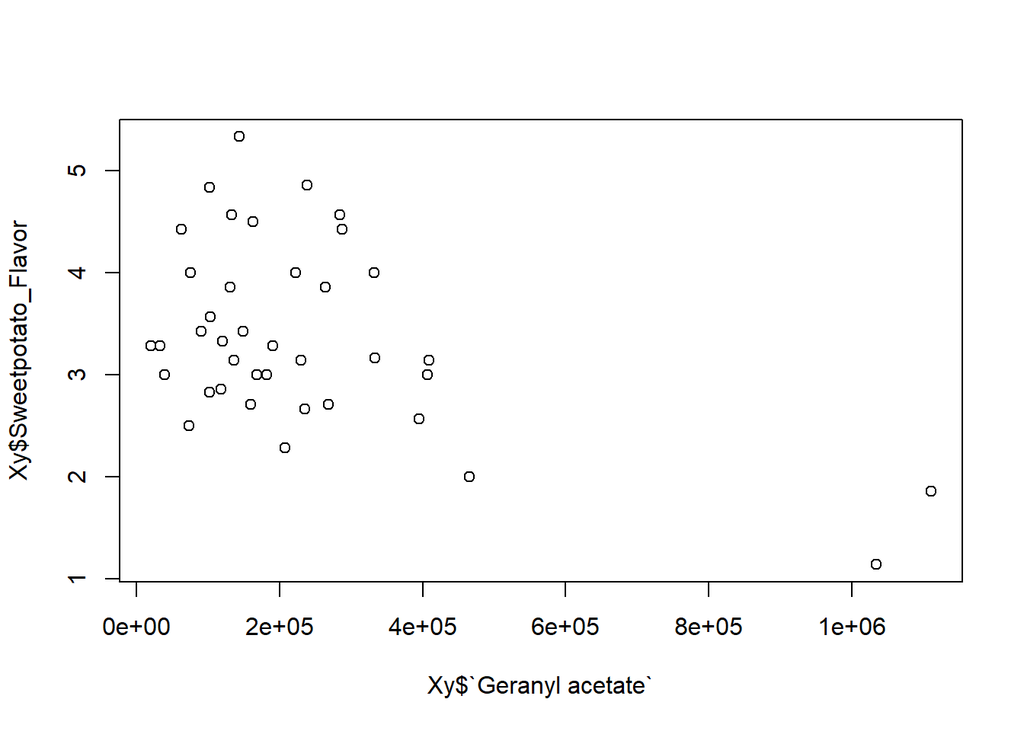

```r
plot(Xy$`Geranyl acetate`,Xy$Sweetpotato_Flavor)
```

# Generalization

```r
createModelErrors<-function(dataf,nfit){

  #error matrix rows is num models cols is num reps
  Errors=matrix(NA,4,nfit)

for(iter in 1:nfit){
  #train test data
  train_test<-trte(dataf)
  train<-train_test[[1]]
  test<-train_test[[2]]

  ## Training control params
  cv <- trainControl(method = "cv",number = 5)



    #pcr

      ## Set K=30
    pcgrid <- expand.grid(ncomp = 1:20)
    ## Fit the model
    pcr_fit <- train(Sweetpotato_Flavor ~ .,
                     data = train,
                     method = "pcr",
                     tuneGrid = pcgrid,
                     trControl = cv,
                     preProcess=c("scale"))


    #pls

    ## Set K=30
  pcgrid <- expand.grid(ncomp = 1:20)
  ## Fit the model
  pls_fit <- train(Sweetpotato_Flavor ~ .,
                   data = train,
                   method = "pls",
                   tuneGrid = pcgrid,
                   trControl = cv,
                   preProcess=c("scale"))


  # lasso


      tuneGridlasso <- expand.grid(alpha = 1, lambda = seq(0.0001, 1, length = 40))


      lasso_fit <- train(
        Sweetpotato_Flavor ~.,
        data = train,
        method = "glmnet",
        trControl = cv,
        tuneGrid =tuneGridlasso,
        preProcess=c("scale"))




    #elastic net


    tuneGridenet <- expand.grid(alpha = seq(0,1,length=10), lambda = seq(0.0001, 1, length = 40))


    enet_fit <- train(
      Sweetpotato_Flavor ~.,
      data = train,
      method = "glmnet",
      trControl =cv,
      tuneGrid =tuneGridenet,
      preProcess=c("scale")
    )




  Errors[,iter]= c(crmse(enet_fit,test),
                   crmse(lasso_fit,test),
                   crmse(pls_fit,test),
                   crmse(pcr_fit,test))

  print(iter)
}

  test_errors<-data.frame(Models=c("Elastic","Lasso","PLS","PCR"),
           RMSE=rowMeans(Errors))




return(list(test_errors,Errors))

}
```

```r
bootconfint<-function(x,B=1000,level=.95){
  # bootstrap conf int
  # data is a vector

  many_means=replicate(B,mean(sample(x,length(x),replace=T)))

  # quantile
  upper<-quantile(many_means,level+(1-level)/2)
  lower<-quantile(many_means,(1-level)/2)

  return(c(lower,upper))
}
```

```r
#test_errors_new<-createModelErrors(Xy,20)
load("test_errorf.Rdata")
load("Error20Reped.Rdata")
test_errors<-test_errors_new
errordf<-test_errors[[1]]
errormat<-test_errors[[2]]
colnames(errordf)[2]<-"Average Test Set RMSE"
  knitr::kable(errordf[order(errordf$`Average Test Set RMSE`,decreasing = F),],caption="Test Errors")
```

Test Errors

|  | Models | Average Test Set RMSE |
| --- | --- | --- |
| 1 | Elastic | 0.6467065 |
| 3 | PLS | 0.7462702 |
| 2 | Lasso | 0.7512389 |
| 4 | PCR | 0.7921066 |

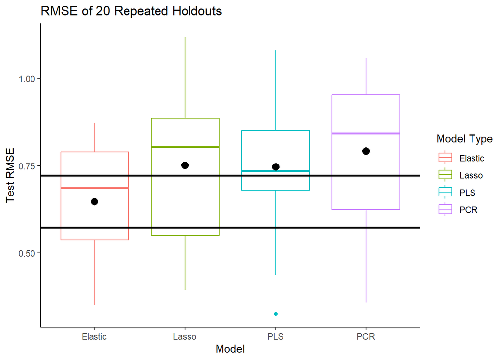

```r
all_errors<-data.frame(t(errormat))
colnames(all_errors)<-errordf$Models


all_errors$ind<-1:20
#all erros for models we want
all_errors<-all_errors%>%dplyr::select(Elastic,Lasso,PLS,PCR,ind)

emat_long<-melt(all_errors,id=c("ind"))

# boot strap confidence interval
bootcfint<-bootconfint(all_errors$Elastic,level = .95,B=1000)

ggplot(emat_long,aes(x=variable,y=value,col=variable))+
  geom_boxplot()+
  theme_classic()+
  stat_summary(fun=mean, geom="point", shape=20, size=5, color="black", fill="black")+
  labs(y="Test RMSE",
       x="Model",
       title="RMSE of 20 Repeated Holdouts",
       color="Model Type")+
  geom_hline(yintercept = unname(bootcfint[1]),
             linewidth=1)+
  geom_hline(yintercept = unname(bootcfint[2]),
             linewidth=1)
```

```r
mean_elastic_error<-emat_long%>%group_by(variable)%>%summarise_all(mean)%>%filter(variable=="Elastic")%>%select(value)

std_error<-emat_long%>%group_by(variable)%>%summarise_all(sd)%>%filter(variable=="Elastic")%>%select(value)


mean_elastic_error+c(-1,1)*std_error
```

```
##       value
## 1 0.4786249
```

- Lowest Median and Average Error comes from Elastic Net Regression
- We recommend you use these models for prediction

```r
get_repped_ennet_importances<-function(dataf,nfit){

# list of important coefs from each nfit
Important_coefs<-vector(mode = "list", length = nfit)

for(iter in 1:nfit){
  #train test data
  train_test<-trte_seed(dataf,seedv=iter)
  train<-train_test[[1]]
  test<-train_test[[2]]


  # elastic net is trained

   cv <- trainControl(method = "cv",number = 5)
    tuneGridenet <- expand.grid(alpha = seq(0,1,length=10), lambda = seq(0.0001, 1, length = 40))


    enet_fit <- train(
      Sweetpotato_Flavor ~.,
      data = train,
      method = "glmnet",
      trControl =cv,
      tuneGrid =tuneGridenet,
      preProcess=c("scale")
    )


  # importance of variables from one lasso run


  # best lambda
  lambda_use <- min(enet_fit$finalModel$lambda[enet_fit$finalModel$lambda >=                    enet_fit$bestTune$lambda])
  #position in df
  position <- which(enet_fit$finalModel$lambda == lambda_use)
  # get all coefs from this model
  df_enet_coef<-data.frame(coef(enet_fit$finalModel)[, position])
  # select important rows that are postive!
  colnames(df_enet_coef)<-c("Value")
  df_enet_coef%>%filter(Value!=0)
  # for the iteration of the list store "important" values
  Important_coefs[[iter]]<-rownames(df_enet_coef%>%filter(Value!=0))
}


  agg_important_coefs<-Reduce(intersect,Important_coefs)




return(agg_important_coefs)
}
```

## What to use for your modeling

```r
get_repped_lasso_importances<-function(dataf,nfit){

# list of important coefs from each nfit
Important_coefs<-vector(mode = "list", length = nfit)

for(iter in 1:nfit){
  #train test data
  train_test<-trte(dataf)
  train<-train_test[[1]]
  test<-train_test[[2]]


  # lasso is trained

         cv <- trainControl(method = "cv",number = 5)
      tuneGridlasso <- expand.grid(alpha = 1, lambda = seq(0.0001, 1, length = 40))


      lasso_fit <- train(
        Sweetpotato_Flavor ~.,
        data = train,
        method = "glmnet",
        trControl = cv,
        tuneGrid =tuneGridlasso,
        preProcess=c("scale"))

  # importance of variables from one lasso run


  # best lambda
  lambda_use <- min(lasso_fit$finalModel$lambda[lasso_fit$finalModel$lambda >= lasso_fit$bestTune$lambda])
  #position in df
  position <- which(lasso_fit$finalModel$lambda == lambda_use)
  # get all coefs from this model
  df_lasso_coef<-data.frame(coef(lasso_fit$finalModel)[, position])
  # select important rows that are postive!
  colnames(df_lasso_coef)<-c("Value")
  df_lasso_coef%>%filter(Value!=0)
  # for the iteration of the list store "important" values
  Important_coefs[[iter]]<-rownames(df_lasso_coef%>%filter(Value!=0))
}


  agg_important_coefs<-Reduce(intersect,Important_coefs)




return(agg_important_coefs)
}
```

```r
# importance measure for PLS
get_repped_pls_importances<-function(dataf,nfit){

# list of important coefs from each nfit
Important_coefs<-vector(mode = "list", length = nfit)

for(iter in 1:nfit){
  #train test data
  train_test<-trte(dataf)
  train<-train_test[[1]]
  test<-train_test[[2]]


  # pls is trained

  cv <- trainControl(method = "cv",number = 5)

  ## Set K=30
  pcgrid <- expand.grid(ncomp = 1:20)
  ## Fit the model
  pls_fit <- train(Sweetpotato_Flavor ~ .,
                   data = train,
                   method = "pls",
                   tuneGrid = pcgrid,
                   trControl = cv,
                   preProcess=c("scale"))

  # importance of variables from one lasso run

  Top_20_vars<-rownames(varImp(pls_fit)[[1]])[order(varImp(pls_fit)[[1]][[1]],decreasing = T)][1:20]
  Important_coefs[[iter]]<-Top_20_vars
}


  agg_important_coefs<-Reduce(intersect,Important_coefs)




return(agg_important_coefs)
}
```

```r
get_repped_ennet_importances(Xy,4)
```

```
## [1] "(Intercept)"
## [2] "`Benzene, 1-(1,5-dimethylhexyl)-4-methyl-`"
## [3] "`Feature 03089`"
## [4] "`Feature 03728`"
## [5] "`Feature 04844`"
## [6] "`Feature 05051`"
## [7] "`Geranyl acetate`"
```

```r
get_repped_ennet_importances(Xy,5)
```

```
## [1] "(Intercept)"
## [2] "`Benzene, 1-(1,5-dimethylhexyl)-4-methyl-`"
## [3] "`Feature 03089`"
## [4] "`Feature 04844`"
## [5] "`Geranyl acetate`"
```

```r
get_repped_ennet_importances(Xy,4)
```

```
## [1] "(Intercept)"
## [2] "`Benzene, 1-(1,5-dimethylhexyl)-4-methyl-`"
## [3] "`Feature 03089`"
## [4] "`Feature 03728`"
## [5] "`Feature 04844`"
## [6] "`Feature 05051`"
## [7] "`Geranyl acetate`"
```

```r
get_repped_lasso_importances(Xy,3 )
```

```
## [1] "(Intercept)"
## [2] "`2-Benzofuranmethanol, 2,4,5,6,7,7a-hexahydro-4,4,7a-trimethyl-, cis-`"
## [3] "`Feature 03728`"
## [4] "`Feature 04844`"
```

```r
get_repped_pls_importances(Xy,5)
```

```
## [1] "`\\`Geranyl acetate\\``"
## [2] "`\\`Feature 03728\\``"
## [3] "`\\`2-Benzofuranmethanol, 2,4,5,6,7,7a-hexahydro-4,4,7a-trimethyl-, cis-\\``"
## [4] "`\\`Bicyclo[2.2.1]heptane, 2-methyl-3-methylene-2-(4-methyl-3-pentenyl)-, (1S-exo)-\\``"
## [5] "`\\`3H-3a,7-Methanoazulene, 2,4,5,6,7,8-hexahydro-1,4,9,9-tetramethyl-, [3aR-(3aŒ±,4Œ≤,7Œ±)]-\\``"
## [6] "`\\`2-Butenal, 3-methyl-\\``"
## [7] "`\\`Feature 04844\\``"
## [8] "`\\`Feature 04996\\``"
```

```r
get_repped_ennet_importances<-function(dataf,nfit){

# list of important coefs from each nfit
Important_coefs<-vector(mode = "list", length = nfit)

for(iter in 1:nfit){
  #train test data
  train_test<-trte(dataf)
  train<-train_test[[1]]
  test<-train_test[[2]]


  # elastic net is trained

   cv <- trainControl(method = "cv",number = 5)
    tuneGridenet <- expand.grid(alpha = seq(0,1,length=10), lambda = seq(0.0001, 1, length = 40))


    enet_fit <- train(
      Sweetpotato_Flavor ~.,
      data = train,
      method = "glmnet",
      trControl =cv,
      tuneGrid =tuneGridenet,
      preProcess=c("scale")
    )


  # importance of variables from one lasso run


  # best lambda
  lambda_use <- min(enet_fit$finalModel$lambda[enet_fit$finalModel$lambda >=                    enet_fit$bestTune$lambda])
  #position in df
  position <- which(enet_fit$finalModel$lambda == lambda_use)
  # get all coefs from this model
  df_enet_coef<-data.frame(coef(enet_fit$finalModel)[, position])
  # select important rows that are postive!
  colnames(df_enet_coef)<-c("Value")
  df_enet_coef%>%filter(Value!=0)
  # for the iteration of the list store "important" values
  Important_coefs[[iter]]<-rownames(df_enet_coef%>%filter(Value!=0))
}


  agg_important_coefs<-Reduce(intersect,Important_coefs)




return(agg_important_coefs)
}
```

# Code to use for your modeling

This function creates the test train split using our data.

```r
# test train function
trte<-function(dataf,p=.8){

  tr_id<-sample(1:nrow(dataf),p*nrow(dataf))

  train<-dataf[tr_id,]

  test<-dataf[-tr_id,]

  return(list(train,test))
}

# this function splits data based on a set seed
trte_seed<-function(dataf,p=.8,seedv=123){

  set.seed(seedv)
  tr_id<-sample(1:nrow(dataf),p*nrow(dataf))

  train<-dataf[tr_id,]

  test<-dataf[-tr_id,]

  return(list(train,test))
}
```

This function computes the root mean square error. We use this measure to compute error.

```r
# function to compute test set RMSE on the spfc variable given a model and test set
crmse<-function(model,test,var="Sweetpotato_Flavor"){

  preds<-predict(model,test)

  obs<-test[,var]

  rmse<-sqrt( mean((preds-obs)^2))

  return(rmse)
}
```

This function will let us get the best result in terms of cross validation error.

```r
# gets the best tuned model from a caret fitted model
get_best_result = function(caret_fit) {
  best = which(rownames(caret_fit$results) == rownames(caret_fit$bestTune))
  best_result = caret_fit$results[best, ]
  rownames(best_result) = NULL
  best_result
}
```

# Reading in Data

- We only deal with the 40 observations that have record for at least one VOC

We make the test train split here.

```r
# we make the test train split here
 train_test<-trte_seed(Xy,seedv = 8768776)
  train<-train_test[[1]]
  test<-train_test[[2]]
```

```r
# gives you the possible values of alpha and lambda used
tuneGrid <- expand.grid(alpha = seq(0,1,length=10), lambda = seq(0.0001, 1, length = 40))

# elastic net training model
# use 5 fold cross validation
enet_fit <- train(
  Sweetpotato_Flavor ~.,
  data = train,
  method = "glmnet",
  trControl = trainControl("cv", number = 5),
  tuneGrid =tuneGrid,
  preProcess=c("scale")
)
```

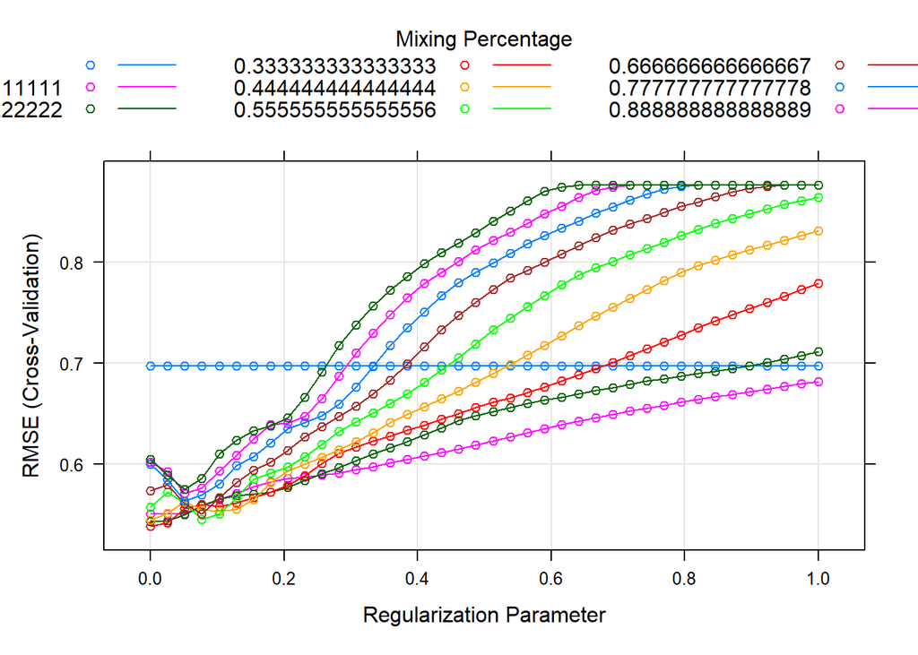

```r
# using the get_best_result function
best_enn<-get_best_result(enet_fit)
plot(enet_fit)
```

```r
best_enn
```

```
##       alpha lambda      RMSE  Rsquared      MAE     RMSESD RsquaredSD
## 1 0.3333333  1e-04 0.5386276 0.6614214 0.412536 0.09918753  0.2982309
##        MAESD
## 1 0.03625086
```

Below we print the “important” coefficients form one holdout of our model. You can interpret these coefficients as standard coefficients like OLS.

```r
print_nonzero_coef<-function(enet_fit){


  # best lambda
lambda_use <- min(lasso_fit$finalModel$lambda[lasso_fit$finalModel$lambda >= lasso_fit$bestTune$lambda])
  #position in df
position <- which(lasso_fit$finalModel$lambda == lambda_use)


df_enet_coef<-data.frame(coef(enet_fit$finalModel)[, position])
# select important rows that are postive!
colnames(df_enet_coef)<-c("Value")
return(df_enet_coef%>%filter(Value!=0))
}


print_nonzero_coef(enet_fit)
```

```
##                                                                                          Value
## (Intercept)                                                                        3.335235489
## `(R)-3,5,5-Trimethylcyclohex-3-en-1-ol`                                           -0.040383775
## `2-Benzofuranmethanol, 2,4,5,6,7,7a-hexahydro-4,4,7a-trimethyl-, cis-`            -0.088942308
## `2-Butenal, 3-methyl-`                                                            -0.060832901
## `3-Hexen-1-ol...78`                                                                0.034116505
## `3-Hexen-1-ol, (Z)-`                                                               0.002497719
## `Benzene, 1-(1,5-dimethyl-4-hexenyl)-4-methyl-...100`                             -0.049626904
## `Benzene, 1-(1,5-dimethylhexyl)-4-methyl-`                                        -0.051793949
## `Bicyclo[2.2.1]heptane, 2-methyl-3-methylene-2-(4-methyl-3-pentenyl)-, (1S-exo)-` -0.011693577
## `Butanenitrile, 2-methyl-`                                                        -0.025406724
## `Butanoic acid, 3-methyl-, 3-methylbutyl ester`                                    0.017698962
## `Ethyl Acetate`                                                                    0.008305288
## `Feature 00422`                                                                    0.069721076
## `Feature 00702`                                                                   -0.027568186
## `Feature 01081`                                                                   -0.005799303
## `Feature 01086`                                                                    0.007241848
## `Feature 01901`                                                                   -0.012790830
## `Feature 02060`                                                                    0.112261214
## `Feature 02170`                                                                   -0.028125326
## `Feature 02259`                                                                    0.031078182
## `Feature 02935`                                                                    0.003090824
## `Feature 02991`                                                                    0.079196033
## `Feature 03089`                                                                    0.172574754
## `Feature 03728`                                                                   -0.088597140
## `Feature 03748`                                                                   -0.053628720
## `Feature 03955`                                                                    0.058074402
## `Feature 04106`                                                                    0.032695830
## `Feature 04198`                                                                    0.023209510
## `Feature 04277`                                                                   -0.013354103
## `Feature 04356`                                                                    0.015220250
## `Feature 04402`                                                                   -0.013397449
## `Feature 04844`                                                                    0.181450560
## `Feature 05051`                                                                    0.054674645
## `Feature 05054`                                                                    0.010296159
## `Feature 05059`                                                                    0.045021479
## `Feature 05306`                                                                    0.075498049
## `Feature 05386`                                                                    0.008765362
## `Feature 05593`                                                                   -0.034197042
## `Feature 05596`                                                                   -0.009593551
## `Feature 05673`                                                                   -0.053561602
## `Furan, 2-ethyl-`                                                                  0.006851396
## `Geranyl acetate`                                                                 -0.148786096
## Pyridine                                                                           0.012799143
```

Here are the predictions for our model

```r
predict(enet_fit,test)
```

```
##        1       11       15       22       24       29       37       38
## 3.383722 4.011963 4.078034 3.028833 4.107367 2.194116 2.795890 2.872734
```

Here are the actual values in our test set.

```r
test$Sweetpotato_Flavor
```

```
## [1] 4.833333 3.571429 3.166667 3.285714 3.142857 1.857143 3.000000 2.857143
```

We can plot these results. We would expect “perfect” predictions to be on a straight line.

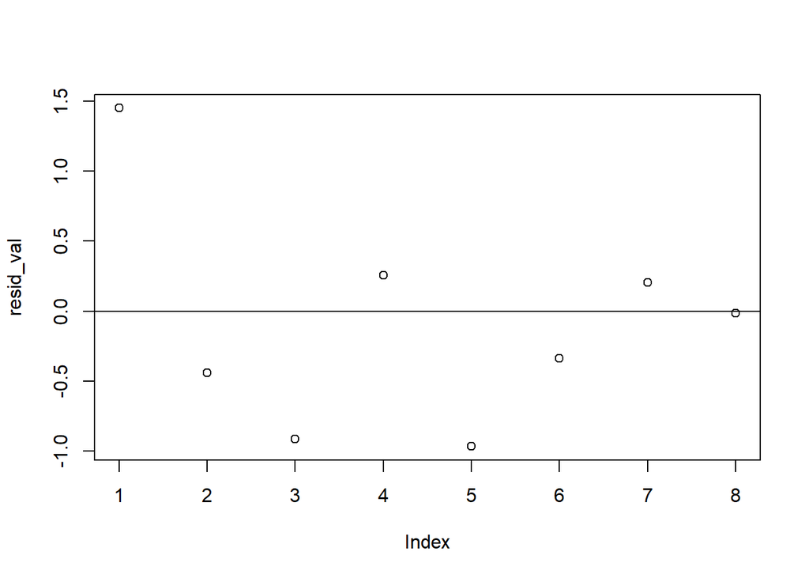

```r
resid_val<-test$Sweetpotato_Flavor-predict(enet_fit,test)
plot(resid_val)
abline(h=0)
```

The test set error for this model is:

```r
crmse(enet_fit,test)
```

```
## [1] 0.7312451
```

In other words the average difference (penalizing more extreme values) between values predicted by a model and the actual values is about 0.7312451 flavor points.